# Analysis of US Consumer Price Index

Mehedi Hasan Jim

2025-07-06

We will use the US Consumer Price Index (CPI) data set from the *tseries* package.

The data set is part of *NelPlo data.*

```r
data(NelPlo, package = "tseries")
head(cpi)
```

```
## Time Series:
## Start = 1860
## End = 1865
## Frequency = 1
## [1] 3.295837 3.295837 3.401197 3.610918 3.871201 3.850148
```

```r
cpi <- ts(cpi,start = 1860, end = 1988)
```

## Test and Training Set

To understand which forecasting method performs the best it’s necessary to evaluate them based on training and testing data. We take the last 8 years for testing data.

```r
library(tidyverse)
library(tseries)
library(forecast)
library(urca)
cpi <- ts(cpi,start = 1860, end = 1988)
cpi.train <- window(cpi, end = 1980)
cpi.test <- window(cpi, start = 1981)
head(cpi.test)
```

```
## Time Series:
## Start = 1981
## End = 1986
## Frequency = 1
## [1] 5.607122 5.666905 5.698524 5.740791 5.775783 5.794200
```

## ploting the data

It’s essential to plot the data to understand it. Plotting the data will help to get idear about the nature of the data and the potential models that can be applied.

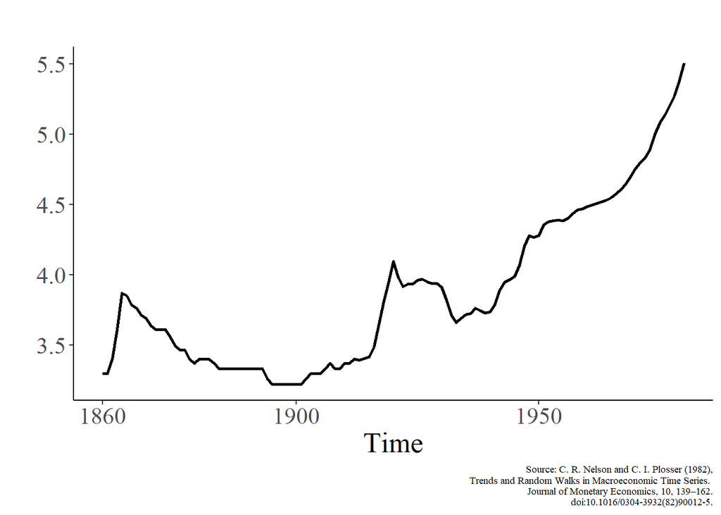

```r
autoplot(cpi.train, linewidth = 1)+
  labs(tittle = "Consumer Price Index: Training Data",
       y= "",
       caption = "Source: C. R. Nelson and C. I. Plosser (1982),\n Trends and Random Walks in Macroeconomic Time Series. \n Journal of Monetary Economics, 10, 139–162.\n doi:10.1016/0304-3932(82)90012-5.")+
  scale_x_continuous(breaks= c(1860, 1900, 1950, 1988))+
  theme_classic()+
  theme(text = element_text(size = 20, family = "serif"),
        plot.caption = element_text(size = 7))
```

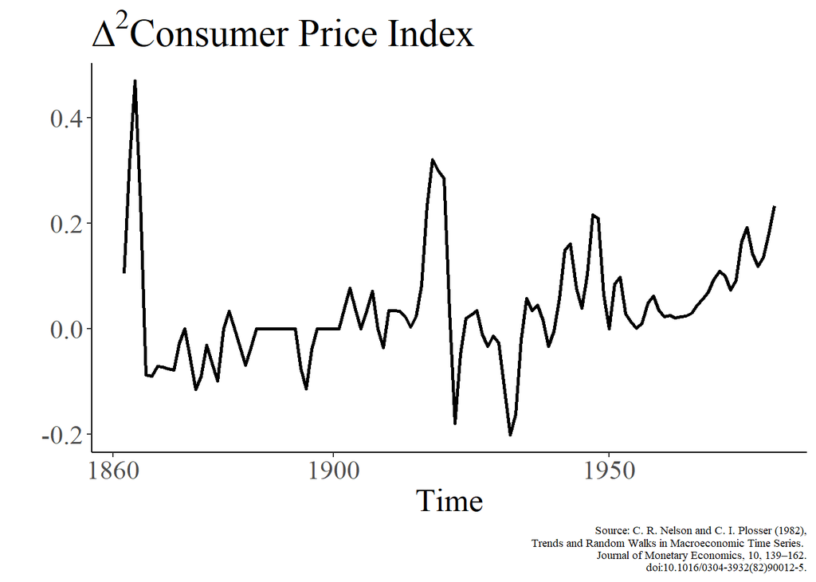

```r
autoplot(diff(cpi.train,2), linewidth = 1)+
  labs(title= expression(Delta^2 * "Consumer Price Index"), y = "",
                 caption = "Source: C. R. Nelson and C. I. Plosser (1982),\n Trends and Random Walks in Macroeconomic Time Series. \n Journal of Monetary Economics, 10, 139–162.\n doi:10.1016/0304-3932(82)90012-5.")+
  scale_x_continuous(breaks= c(1860, 1900, 1950, 1988))+
  theme_classic()+
  theme(text = element_text(size = 20, family = "serif"),
        plot.caption = element_text(size = 7))
```

Seems like differencing is making it trend stationary. Need to ensure wheater the variable at level and/or variable at first difference has unit root or not. Note: A series with unit root has time variant mean and/or variance.

Now let’s explore the unit root, ACF and PACF to understand what will be the potential values of p,d and q in the *ARIMA* model

```r
urca::ur.df(cpi.train,type = "drift") |>summary() # alternative tests are kpss, ers, pp, sp, za tests from the urca package
```

```
##
## ###############################################
## # Augmented Dickey-Fuller Test Unit Root Test #
## ###############################################
##
## Test regression drift
##
##
## Call:
## lm(formula = z.diff ~ z.lag.1 + 1 + z.diff.lag)
##
## Residuals:
##       Min        1Q    Median        3Q       Max
## -0.210887 -0.013672 -0.003596  0.014998  0.141449
##
## Coefficients:
##              Estimate Std. Error t value Pr(>|t|)
## (Intercept) -0.018622   0.031539  -0.590    0.556
## z.lag.1      0.006902   0.008197   0.842    0.402
## z.diff.lag   0.601908   0.078320   7.685 5.38e-12 ***
## ---
## Signif. codes:  0 '***' 0.001 '**' 0.01 '*' 0.05 '.' 0.1 ' ' 1
##
## Residual standard error: 0.04628 on 116 degrees of freedom
## Multiple R-squared:  0.3811, Adjusted R-squared:  0.3705
## F-statistic: 35.72 on 2 and 116 DF,  p-value: 8.176e-13
##
##
## Value of test-statistic is: 0.842 1.8483
##
## Critical values for test statistics:
##       1pct  5pct 10pct
## tau2 -3.46 -2.88 -2.57
## phi1  6.52  4.63  3.81
```

The unit root test (Null: The series has unit root.) shows that CPI has unit root at level.

```r
urca::ur.df(diff(cpi.train),type = "drift") |>summary()
```

```
##
## ###############################################
## # Augmented Dickey-Fuller Test Unit Root Test #
## ###############################################
##
## Test regression drift
##
##
## Call:
## lm(formula = z.diff ~ z.lag.1 + 1 + z.diff.lag)
##
## Residuals:
##       Min        1Q    Median        3Q       Max
## -0.200573 -0.014820 -0.000801  0.019576  0.119296
##
## Coefficients:
##              Estimate Std. Error t value Pr(>|t|)
## (Intercept)  0.008329   0.004295   1.939   0.0549 .
## z.lag.1     -0.473913   0.079481  -5.963 2.79e-08 ***
## z.diff.lag   0.253094   0.089841   2.817   0.0057 **
## ---
## Signif. codes:  0 '***' 0.001 '**' 0.01 '*' 0.05 '.' 0.1 ' ' 1
##
## Residual standard error: 0.04422 on 115 degrees of freedom
## Multiple R-squared:  0.2362, Adjusted R-squared:  0.2229
## F-statistic: 17.78 on 2 and 115 DF,  p-value: 1.864e-07
##
##
## Value of test-statistic is: -5.9626 17.7772
##
## Critical values for test statistics:
##       1pct  5pct 10pct
## tau2 -3.46 -2.88 -2.57
## phi1  6.52  4.63  3.81
```

The test result shows that the first differnce series dos not have unit root.

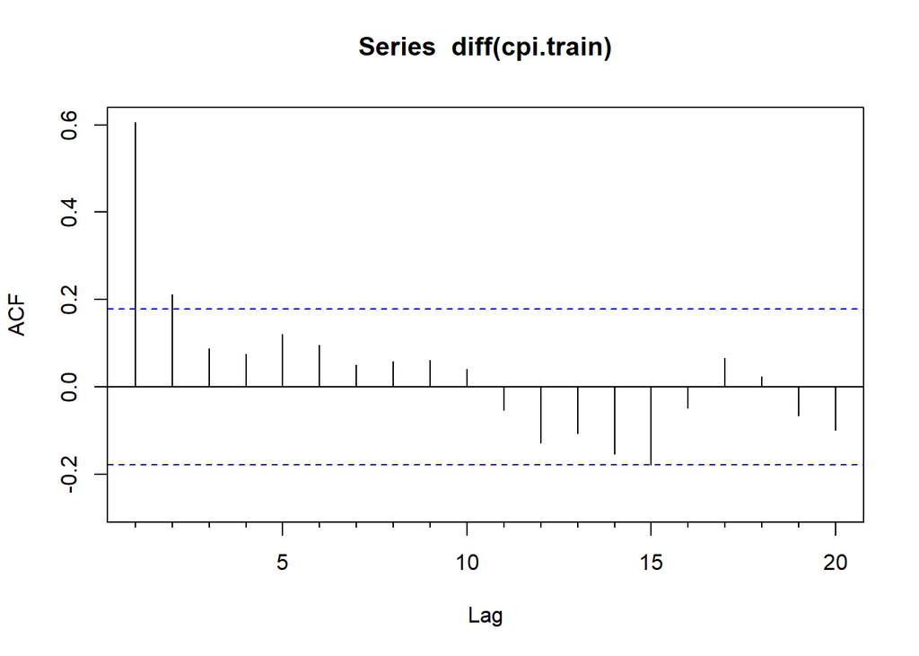

```r
Acf(diff(cpi.train))
```

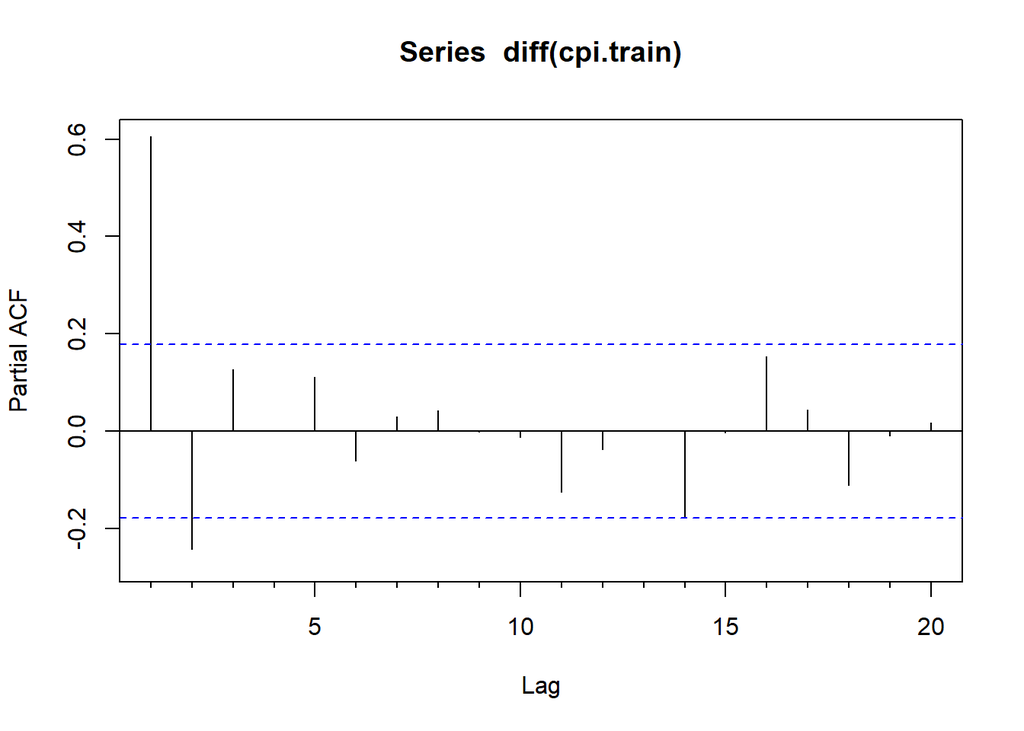

```r
Pacf(diff(cpi.train))
```

```r
cpi.fit.auto.arima <- auto.arima(cpi.train, seasonal = F)
```

## forecast using auto.arima

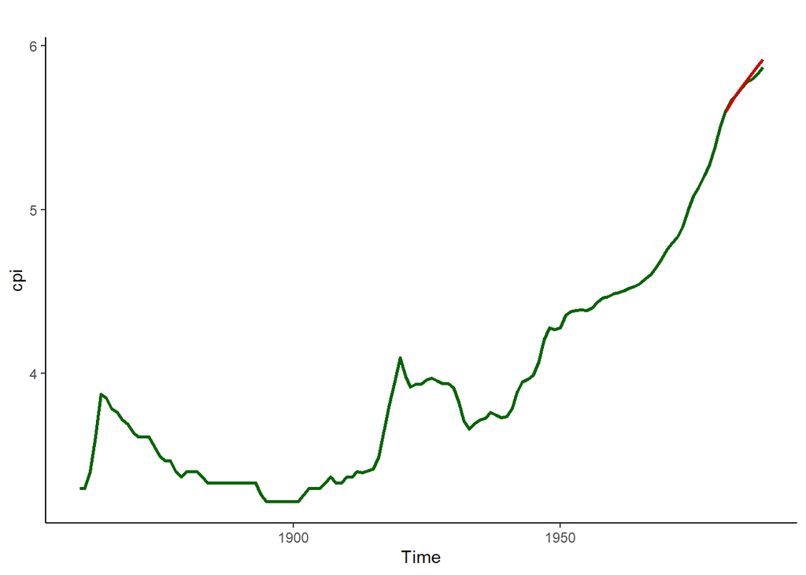

```r
forecast.auto.arima <- cpi.fit.auto.arima%>% forecast(h = 8)
autoplot(cpi, color = "darkgreen", size =1, series = "CPI")+
  autolayer(forecast.auto.arima, PI =F, color = "darkred", size = 1, series = "Arima Prediction")+
  theme_classic()
```

Notice that the forecasted values are very close to the real values. Remember that the last 8 years were not used in training. Seems a good fit. Let’s evaluate the fit.

## ARIMA fit Evaluation

```r
accuracy(forecast.auto.arima, cpi.test) %>% round(3)
```

```
##                  ME  RMSE   MAE    MPE  MAPE  MASE   ACF1 Theil's U
## Training set  0.002 0.044 0.028  0.046 0.724 0.696 -0.015        NA
## Test set     -0.015 0.027 0.021 -0.260 0.366 0.537  0.680     0.728
```